# Module_4_Python_Data_Visualization_Seaborn

## **Seaborn**

"Seaborn is a Python data visualization library based on matplotlib. It provides a high-level interface for drawing attractive and informative statistical graphics" (Source: Seaborn Website)

Seaborn also has a great website for graph examples/tutorials. You should check: [Here](https://seaborn.pydata.org/)

```python
#import matplotlib and seaborn

import matplotlib.pyplot as plt
import seaborn as sns
```

### Data loading

Seaborn has builtin datasets that we can use.

We will be using `tips` dataset from seaborn.

```python
tips = sns.load_dataset('tips')
tips.head()
```

|  | total_bill | tip | sex | smoker | day | time | size |
| --- | --- | --- | --- | --- | --- | --- | --- |
| 0 | 16.99 | 1.01 | Female | No | Sun | Dinner | 2 |
| 1 | 10.34 | 1.66 | Male | No | Sun | Dinner | 3 |
| 2 | 21.01 | 3.50 | Male | No | Sun | Dinner | 3 |
| 3 | 23.68 | 3.31 | Male | No | Sun | Dinner | 2 |
| 4 | 24.59 | 3.61 | Female | No | Sun | Dinner | 4 |

```python
tips.shape
```

```
(244, 7)
```

```python
tips.info()
```

```
<class 'pandas.core.frame.DataFrame'>
RangeIndex: 244 entries, 0 to 243
Data columns (total 7 columns):
 #   Column      Non-Null Count  Dtype
---  ------      --------------  -----
 0   total_bill  244 non-null    float64
 1   tip         244 non-null    float64
 2   sex         244 non-null    category
 3   smoker      244 non-null    category
 4   day         244 non-null    category
 5   time        244 non-null    category
 6   size        244 non-null    int64
dtypes: category(4), float64(2), int64(1)
memory usage: 7.4 KB
```

```python
tips.describe()
```

|  | total_bill | tip | size |
| --- | --- | --- | --- |
| count | 244.000000 | 244.000000 | 244.000000 |
| mean | 19.785943 | 2.998279 | 2.569672 |
| std | 8.902412 | 1.383638 | 0.951100 |
| min | 3.070000 | 1.000000 | 1.000000 |
| 25% | 13.347500 | 2.000000 | 2.000000 |
| 50% | 17.795000 | 2.900000 | 2.000000 |
| 75% | 24.127500 | 3.562500 | 3.000000 |
| max | 50.810000 | 10.000000 | 6.000000 |

## **Distribution plots**

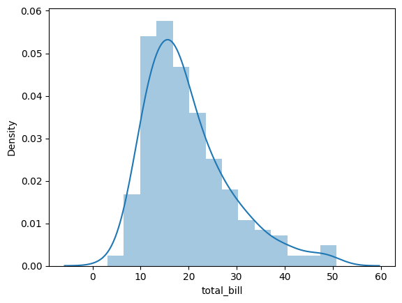

```python
#It shows the distribution of observations.
sns.distplot(tips['total_bill'])
```

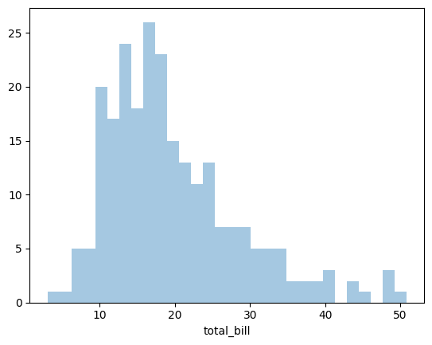

```python
sns.distplot(tips['total_bill'],kde=False,bins=30)
```

## jointplot

`jointplot()` allows you to plot bivariate data. These are kinds of **bivariate** plots:

- scatter
- reg
- resid
- kde
- hex

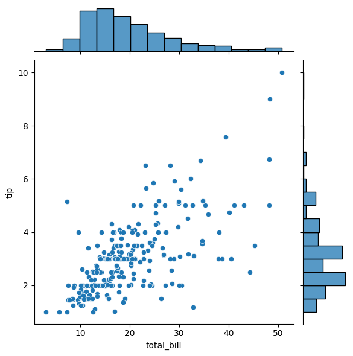

```python
sns.jointplot(x='total_bill',y='tip',data=tips,kind='scatter')
```

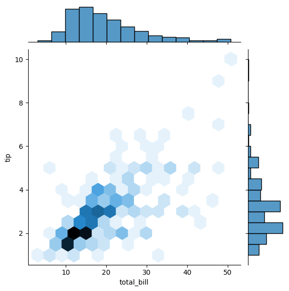

```python
sns.jointplot(x='total_bill',y='tip',data=tips,kind='hex')
```

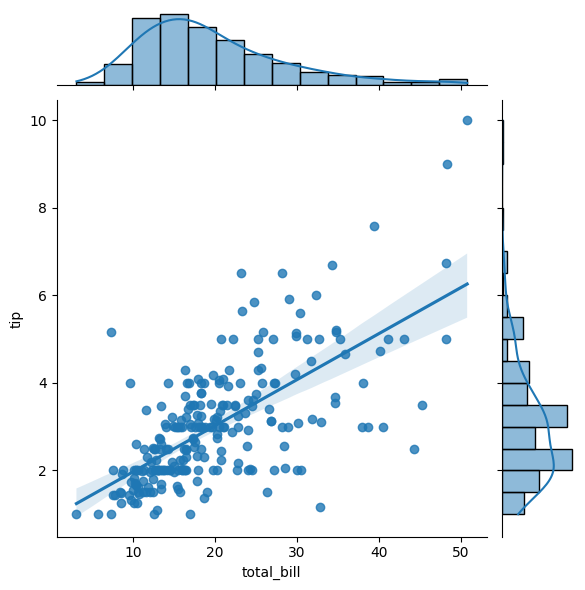

```python
sns.jointplot(x='total_bill',y='tip',data=tips,kind='reg')
```

## Pairplot

Plot pairwise relationships across an entire dataframe (numerical columns)

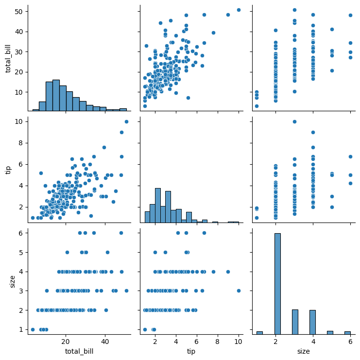

```python
sns.pairplot(tips)
```

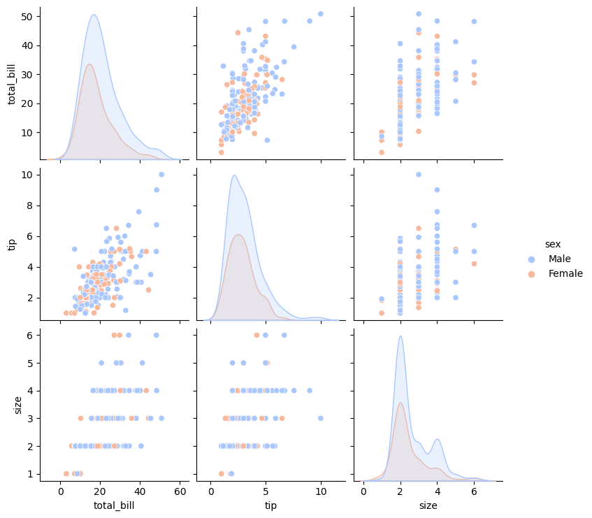

```python
sns.pairplot(tips,hue='sex',palette='coolwarm')
```

## rugplot

draw a dash mark for every point on a univariate distribution

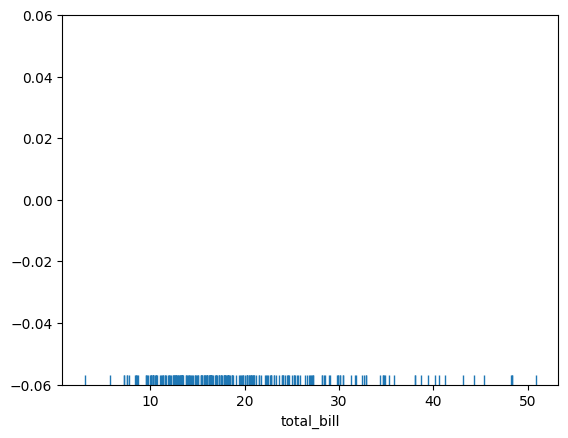

```python
sns.rugplot(tips['total_bill'])
```

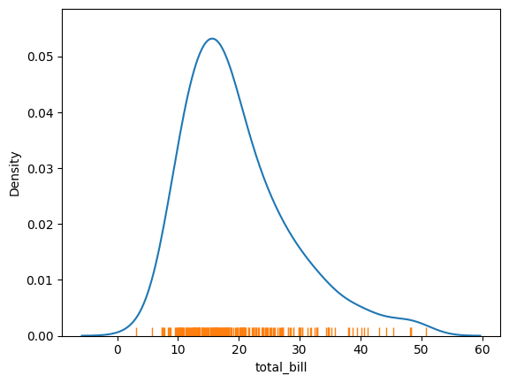

```python
sns.kdeplot(tips['total_bill'])
sns.rugplot(tips['total_bill'])
```

## **Categorical Plots**

Let's see each!

## barplot and countplot

Barplot is a general plot that allows you to aggregate the categorical data(default: mean)

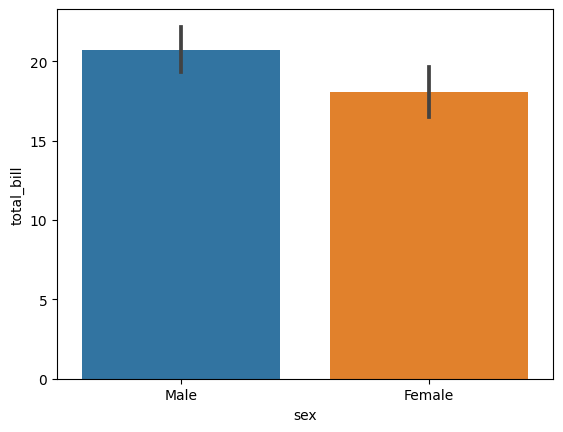

```python
sns.barplot(x='sex',y='total_bill',data=tips)
```

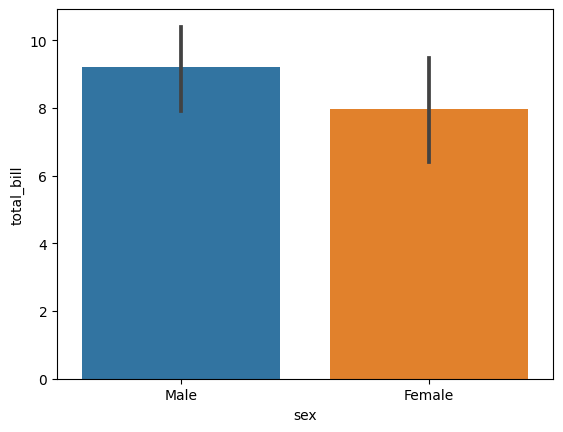

```python
import numpy as np

sns.barplot(x='sex',y='total_bill',data=tips,estimator=np.std)
```

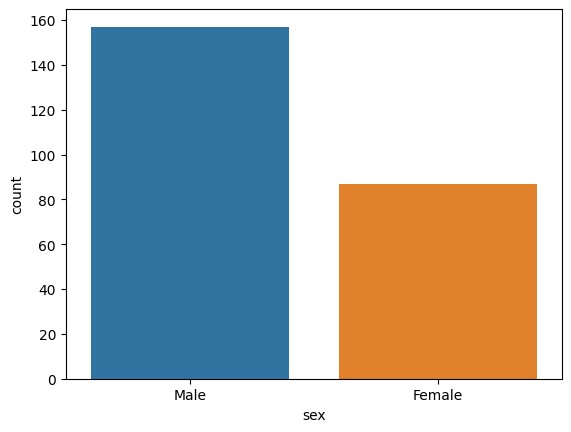

```python
#countplot
#Same with above but it is about the count of occurance

sns.countplot(x='sex',data=tips)
```

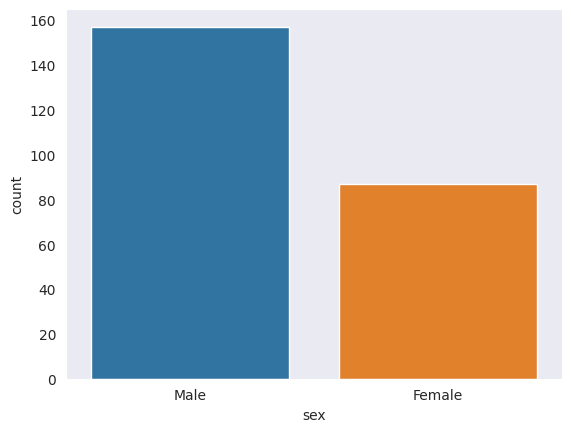

```python
sns.set_style('dark')
sns.countplot(x='sex',data=tips)
```

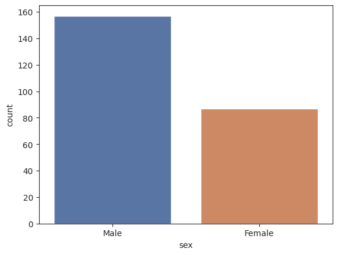

```python
sns.set_style('ticks')
sns.countplot(x='sex',data=tips,palette='deep')
```

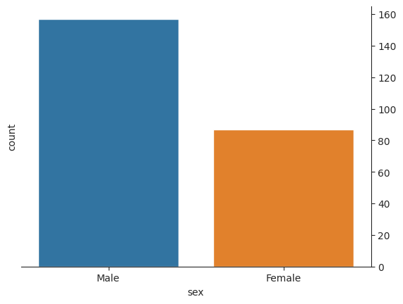

```python
#spine control
sns.countplot(x='sex',data=tips)
sns.despine(left=True, right=False)
#defult is right True. You can pass arguments.
```

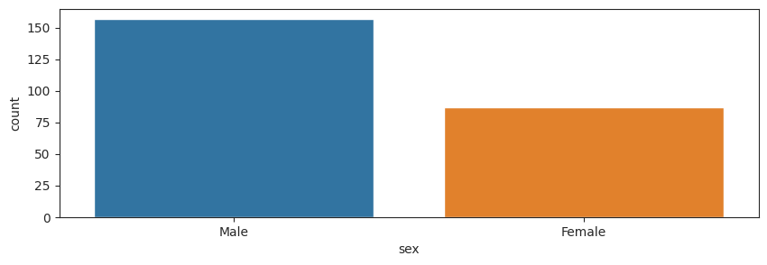

```python
#figsize
plt.figure(figsize=(10,3))
sns.countplot(x='sex',data=tips)
```

## boxplot and violinplot

boxplots and violinplots are used to shown the distribution of categorical data.

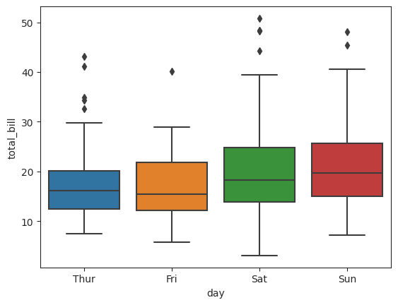

```python
sns.boxplot(x="day", y="total_bill", data=tips)
```

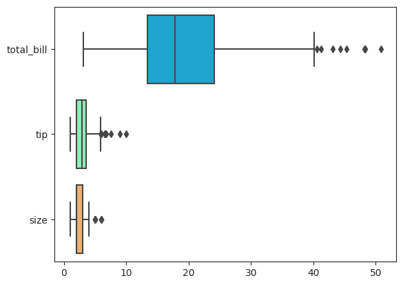

```python
sns.boxplot(data=tips,palette='rainbow',orient='h')
```

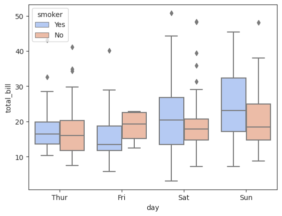

```python
sns.boxplot(x="day", y="total_bill", hue="smoker",data=tips, palette="coolwarm")
```

### violinplot

A violin plot plays a similar role as a box and whisker plot.

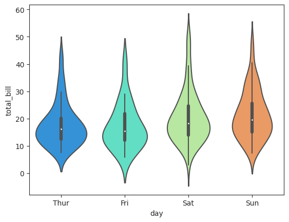

```python
sns.violinplot(x="day", y="total_bill", data=tips,palette='rainbow')
```

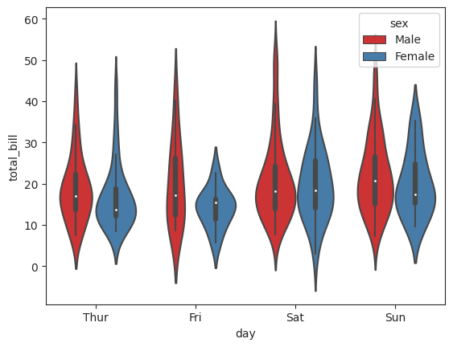

```python
sns.violinplot(x="day", y="total_bill", data=tips,hue='sex',palette='Set1')
```

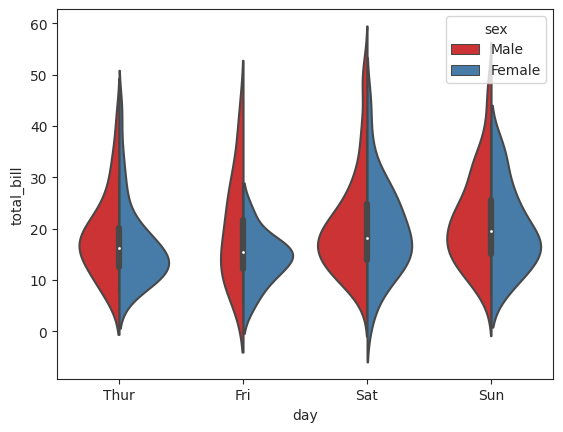

```python
sns.violinplot(x="day", y="total_bill", data=tips,hue='sex',split=True,palette='Set1')
```

## stripplot and swarmplot

The `stripplot` will draw a scatterplot where one variable is categorical.

The `swarmplot` is similar to `stripplot()`, but the points are adjusted so that they do not overlap.

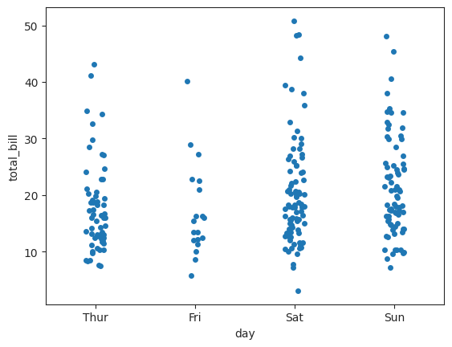

```python
sns.stripplot(x="day", y="total_bill", data=tips)
```

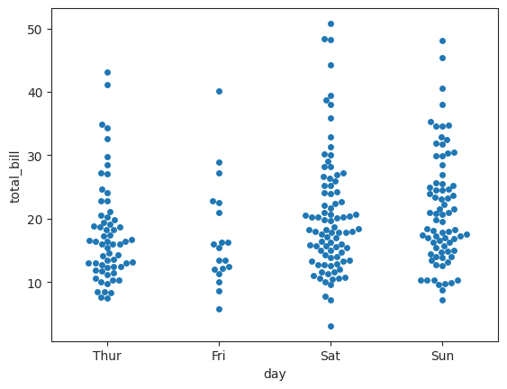

```python
sns.swarmplot(x="day", y="total_bill", data=tips)
```

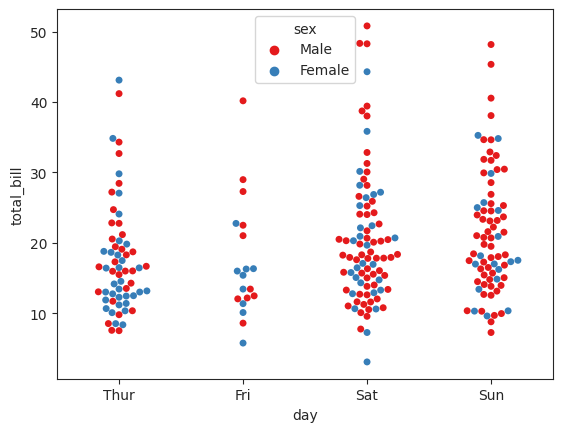

```python
sns.swarmplot(x="day", y="total_bill",hue='sex',data=tips, palette="Set1")
```

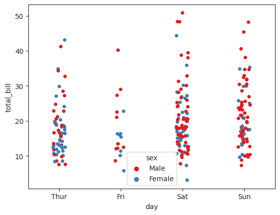

```python
sns.stripplot(x="day", y="total_bill", data=tips,jitter=True,hue='sex',palette='Set1')
```

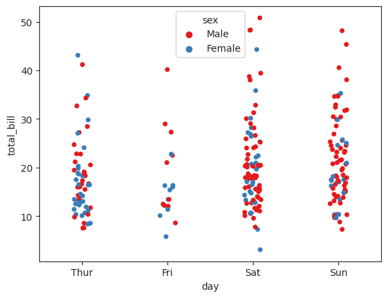

```python
sns.stripplot(x="day", y="total_bill", data=tips,jitter=True,hue='sex',palette='Set1')
```

### Combining Plots

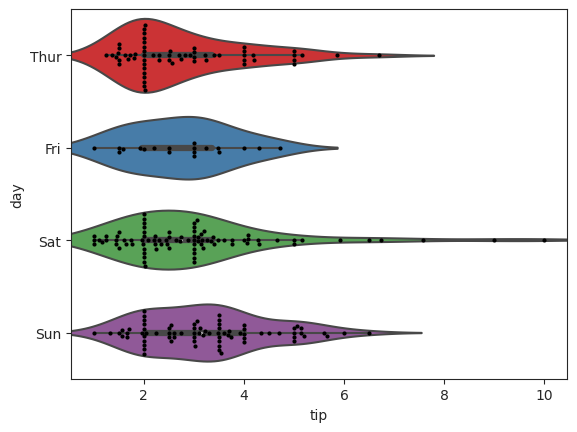

```python
sns.violinplot(x="tip", y="day", data=tips,palette='Set1')
sns.swarmplot(x="tip", y="day", data=tips,color='black',size=3)
```

## Heatmap

Data should be in a matrix form.

```python
# Matrix form for correlation data
tips.corr()
```

|  | total_bill | tip | size |
| --- | --- | --- | --- |
| total_bill | 1.000000 | 0.675734 | 0.598315 |
| tip | 0.675734 | 1.000000 | 0.489299 |
| size | 0.598315 | 0.489299 | 1.000000 |

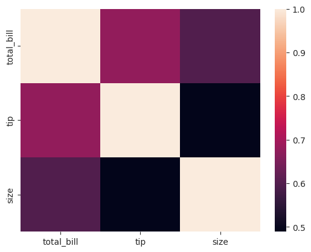

```python
sns.heatmap(tips.corr())
```

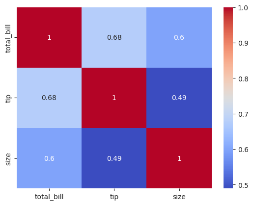

```python
sns.heatmap(tips.corr(),cmap='coolwarm',annot=True)
```

lets use a different data from seaborn

```python
flights = sns.load_dataset('flights')
flights.head()
```

|  | year | month | passengers |
| --- | --- | --- | --- |
| 0 | 1949 | Jan | 112 |
| 1 | 1949 | Feb | 118 |
| 2 | 1949 | Mar | 132 |
| 3 | 1949 | Apr | 129 |
| 4 | 1949 | May | 121 |

```python
flights.pivot_table(values='passengers',index='month',columns='year')
```

| year month | 1949 | 1950 | 1951 | 1952 | 1953 | 1954 | 1955 | 1956 | 1957 | 1958 | 1959 | 1960 |
| --- | --- | --- | --- | --- | --- | --- | --- | --- | --- | --- | --- | --- |
| Jan | 112 | 115 | 145 | 171 | 196 | 204 | 242 | 284 | 315 | 340 | 360 | 417 |
| Feb | 118 | 126 | 150 | 180 | 196 | 188 | 233 | 277 | 301 | 318 | 342 | 391 |
| Mar | 132 | 141 | 178 | 193 | 236 | 235 | 267 | 317 | 356 | 362 | 406 | 419 |
| Apr | 129 | 135 | 163 | 181 | 235 | 227 | 269 | 313 | 348 | 348 | 396 | 461 |
| May | 121 | 125 | 172 | 183 | 229 | 234 | 270 | 318 | 355 | 363 | 420 | 472 |
| Jun | 135 | 149 | 178 | 218 | 243 | 264 | 315 | 374 | 422 | 435 | 472 | 535 |
| Jul | 148 | 170 | 199 | 230 | 264 | 302 | 364 | 413 | 465 | 491 | 548 | 622 |
| Aug | 148 | 170 | 199 | 242 | 272 | 293 | 347 | 405 | 467 | 505 | 559 | 606 |
| Sep | 136 | 158 | 184 | 209 | 237 | 259 | 312 | 355 | 404 | 404 | 463 | 508 |
| Oct | 119 | 133 | 162 | 191 | 211 | 229 | 274 | 306 | 347 | 359 | 407 | 461 |
| Nov | 104 | 114 | 146 | 172 | 180 | 203 | 237 | 271 | 305 | 310 | 362 | 390 |
| Dec | 118 | 140 | 166 | 194 | 201 | 229 | 278 | 306 | 336 | 337 | 405 | 432 |

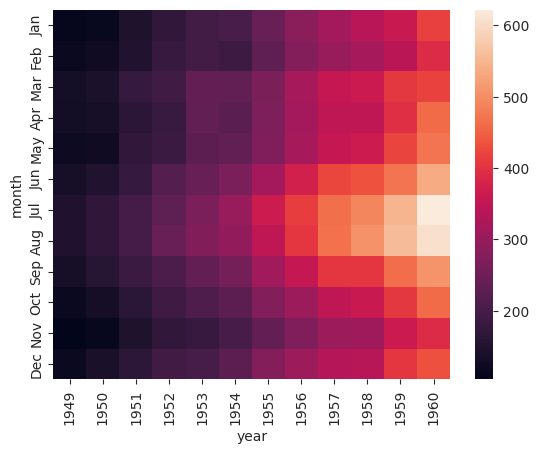

```python
flight2 = flights.pivot_table(values='passengers',index='month',columns='year')
sns.heatmap(flight2)
```

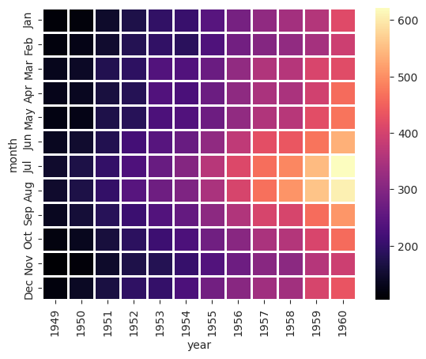

```python
sns.heatmap(flight2,cmap='magma',linecolor='white',linewidths=1)
```